# session1

## 1. Python Programming Essentials

We are now ready to start learning the Python language itself.

### Basic Syntax

```python
# comments start with #
x = 'hola mundo' # use '' or "" for strings
print(x)
```

```
hola mundo
```

#### Primitive Data Types

Variables in Python don't need to be declared, just used for the first time, and can change their type when overwritten.

```python
x = 3
print(type(x))
y = 2.5
print(type(y))
v = 100 < 10
print(type(v))
print(v)
```

```
<class 'int'>
<class 'float'>
<class 'bool'>
False
```

```python
v1 = False
v2 = True
v1 + v2 # boolean arithmetic
```

```
1
```

#### Containers

Collection of objects

##### Lists and Tuples

```python
ϵ = [] # creates an empty list, type \epsilon + tab to automatically get mathematical symbol
ϵ
```

```
[]
```

```python
x = [10,'foo',False] # can combine different data types
type(x)
```

```
list
```

```python
x.append(2.5) # adding a value to a list
x
```

```
[10, 'foo', False, 2.5]
```

```python
for element in x:
    print(element)
```

```
10
foo
False
2.5
```

> Note: Lists in Python are **zero-based**, so the first element is referenced by `x[0]`

```python
x[0]
```

```
10
```

Lists are "mutable" which means they can still be altered after creation

```python
y = [1,2]
y[0] = 10 # assigning new value using index
y
```

```
[10, 2]
```

Tuples are "immutable" lists, i.e. the object cannot be changed.

```python
y = (1,2)
```

```
y[0] = 10
---------------------------------------------------------------------------
TypeError                                 Traceback (most recent call last)
h:\My Drive\CEMFI\2022_PhD\gds4ae_practice_23\session1.ipynb Cell 23 in <cell line: 1>()
----> 1 y[0] = 10

TypeError: 'tuple' object does not support item assignment
```

Both lists and tuples can be "unpacked"

```python
integers = (10, 20, 30)
x, y, z = integers
y
```

```
20
```

To access multiple elements of a list or tuple, you can use Python's **slice notation**.

```python
a = [2, 4, 6, 8]
a[1:3]
```

```
[4, 6]
```

> Note: the general rule is that `a[m:n]` returns `n-m` elements, starting at `a[m]`

```python
a[1:]
```

```
[4, 6, 8]
```

```python
a[-2:] # last two elements
```

```
[6, 8]
```

```python
s = 'cemfi'
s[-2:] # also works on strings
```

```
'fi'
```

##### Sets and Dictionaries

```python
d = {'name':'Frodo','age':33} # dictionaries are like lists but named instead of numbered
d['mission'] = 'to take the Ring to Mount Doom' #New key-value pairs are introduced to the dict like this
type(d)
```

```
dict
```

```python
d
```

```
{'name': 'Frodo', 'age': 33, 'mission': 'to take the Ring to Mount Doom'}
```

```python
d['age']
```

```
33
```

The names `'name'` and `'age'` are *keys* and the objects that they are mapped to are *values*. You can access keys and values using the `items()` method:

```python
for key, value in d.items():
    print(f"The Hobbit's {key} is {value}")
```

```
The Hobbit's name is Frodo
The Hobbit's age is 33
The Hobbit's mission is to take the Ring to Mount Doom
```

Sets are unordered collections without duplicates.

```python
s1 = {'a','b'}
type(s1)
```

```
set
```

```python
s2 = {'b','c'}
s1.intersection(s2)
```

```
{'b'}
```

> Note: you can look at all the variables you created by right-clicking somewhere in the notebook and selecting `Open Variable Inspector`

#### Iterating

You can iterate over iterable objects (`list`, `tuple`, `dict`, `set`) using the `for` loop.

> Note: Python knows the extent of the code block *only from indentation*

Importantly, you can loop without explicit indexing. For example:

```python
x_values = [1, 2, 3]
for x in x_values: # note syntax
    print(x*x)
```

```
1
4
9
```

Instead of:

```python
for i in range(len(x_values)):
    print(x_values[i]*x_values[i])
```

```
1
4
9
```

Here is an example of looping over non-numerical objects:

```python
animals = ['dog','cat','bird']
for animal in animals:
    print(f"The plural of {animal} is {animal + 's'}")
```

```
The plural of dog is dogs
The plural of cat is cats
The plural of bird is birds
```

You could do the same thing using the "list comprehension" tool of Python

```python
plurals = [animal + 's' for animal in animals]
plurals
```

```
['dogs', 'cats', 'birds']
```

`zip()` allows you to step through pairs from two sequences:

```python
countries = ('Japan','Korea','China')
cities = ('Tokyo','Seoul','Beijing')
for country, city in zip(countries,cities):
    print(f"The capital of {country} is {city}")
```

```
The capital of Japan is Tokyo
The capital of Korea is Seoul
The capital of China is Beijing
```

```python
country_dict= {'Japan' : 'Tokyo',
'Korea' : 'Seoul',
'China' : 'Beijing'}
```

```python
japan_tuple = ('Japan', 'Tokyo')
```

```python
country_dict.items()
```

```
dict_items([('Japan', 'Tokyo'), ('Korea', 'Seoul'), ('China', 'Beijing')])
```

```python
for country, city in country_dict.items():
    print(f"The capital of {country} is {city}")
```

```
The capital of Japan is Tokyo
The capital of Korea is Seoul
The capital of China is Beijing
```

If you actually need the index from a list, one option is to use `enumerate()`

```python
letter_list = ['a','b','c']
for index, letter in enumerate(letter_list):
    print(f"letter_list[{index}]='{letter}'")
```

```
letter_list[0]='a'
letter_list[1]='b'
letter_list[2]='c'
```

#### A pair of very useful iteration packages: `itertools` and `tqdm`

Sometimes you want to nest several for loops or combine them with a progress bar such as `tqdm`. The package `itertools` provides ways to combine iterables so that you can have cleaner code. For instance, imagine you want to print all combinations of city and country: we could write

```
for country in countries:
    for city in cities:
        print(f"{city}, {country})
```

or we could use the `itertools` product function that is integrated into tqdm and write:

```python
from tqdm.contrib.itertools import product as tqdmproduct
import time
printstring = ""
for country, city in tqdmproduct(countries, cities, desc = "combining cities and countries"):
    printstring = printstring + (f"\n{city}, {country}")
    time.sleep(0.3)
print(printstring)
```

```
Tokyo, Japan
Seoul, Japan
Beijing, Japan
Tokyo, Korea
Seoul, Korea
Beijing, Korea
Tokyo, China
Seoul, China
Beijing, China
```

#### Comparisons and Logical Operators

```python
x, y = 1, 2
x < y
```

```
True
```

```python
x = 1 # Assignment
x == 2 # Comparison
```

```
False
```

```python
1 != 2
```

```
True
```

```python
1 < 2 and 'g' in 'foo'
```

```
False
```

```python
tup = (1,2,3)
```

```python
4 in tup or 1 in tup
```

```
True
```

```python
1 < 2 or 'g' in 'foo'
```

```
True
```

```python
1 < 2 and not 'g' in 'foo'
```

```
True
```

```python
numbers = [-9, 2.3, -11, 0]

for x in numbers:
    if x < 0:
        print(-1)
    else:
        print(1)
```

```
-1
1
-1
1
```

### Functions

As in any programming language, functions in Python are objects that take a number of inputs, perform an operation on those inputs, and return an output. Functions in Python have two types of inputs, these are positional inputs and named inputs.

#### A function with one positional input:

This function checks a number and tells you if it is positive or negative

```python
def check_negative(x):
    if x < 0:
        return 'negative'
    return 'nonnegative'
check_negative(5)
```

```
'nonnegative'
```

#### A function with two positional inputs:

This function adds the two elements it gets (Note it works with any type, so for instance with strings it appends them)

```python
def sum(a, b):
    return a + b

print(sum(3, 4))
print(sum('3', '4'))
```

```
7
34
```

#### Inputting an arbitrary number of positional inputs: Using `*args`

Creating functions that only take a fixed number of inputs can be very limiting. In our example of a function that adds things, we want the function to have an arbitrary number of inputs. When the inputs are of the same type, Python offers an elegant solution which is to define functions that accept an unpacked tuple of arbitrary size, conventionally named `*args`.

What this means is that we can define a function like this:

```python
def add(*args):
    a = 0
    for i in args:
        a = a + i
    return a
```

Then, this function accepts an arbitrary number of inputs:

```python
print(add(1, 2, 4))
print(add(2,4,4,5,3,54,5,3,3,4,4,4))
```

```
7
95
```

And also an unpacked tuple:

```python
tuple_to_add = (2,4,4,5,3,54,5,3,3)
print(add(*tuple_to_add))
```

```
83
```

#### Functions with named inputs:

Besides positional inputs, which are based on order, functions can have named inputs which always go behind the positional inputs, if there are any. As you will see later, these will be very useful for functions with default inputs.

Here we will make the same adding function as before, but now it has an additional named argument, which is the text that you want to print before seeing the result.

```python
def add(*args, text):
    a = 0
    for i in args:
        a = a + i
    print(f'{text} {a}')

add(*tuple_to_add, text = f'The result of adding up {tuple_to_add} is: ')
```

```
The result of adding up (2, 4, 4, 5, 3, 54, 5, 3, 3) is:  83
```

#### Functions can have default named inputs:

Functions can have inputs which are set by default. For instance, in the function above where it prints a text, it might be very annoying to input the text each time. A solution for this is to create a function where some named inputs have a default, which is done as so:

```python
def add(
    *args,
    text = 'The result of adding up these numbers is: '
    ):
    text = text.replace('these numbers', f'{args}')
    a = 0
    for i in args:
        a = a + i
    print(f'{text} {a}')

##If we do not input any text, the default text is printed:
add(*tuple_to_add)

##If we add a text input, the text that it prints changes:
add(*tuple_to_add, text = 'Adding up these numbers equals: ')
```

```
The result of adding up (2, 4, 4, 5, 3, 54, 5, 3, 3) is:  83
Adding up (2, 4, 4, 5, 3, 54, 5, 3, 3) equals:  83
```

#### Inputting a dictionary of named inputs: using `**kwargs`

The same way that functions can have an arbitrary number of inputs of positional arguments, they can have an arbitrary number of optional named arguments. For example, in the "add" function we will allow it to have inputs that change the style in which the text is printed.

This is better understood when you begin using libraries that call other libraries that call other libraries, since it is used extensively to pass arguments between functions (i.e. function A has its own inputs, but calls itself function B which has its own set of named inputs, and these are passed in the form of optional `**kwargs`). In our example this is the case too, our `add` function will use the enriched `print` function from the `console` package in the `rich` module. As such, the `**kwargs` that we pass into `add` will be those that go straight into the `console.print` function.

`**kwargs` are just a flexible way of having the option of giving many named inputs to a function, but without the need of specifying all of them every time.

```python
from rich.console import Console
from colorama import just_fix_windows_console
```

```python
def add(
    *args,
    text = 'The result of adding up these numbers is: ',
    **kwargs
    ):
    just_fix_windows_console()
    console = Console()
    text = text.replace('these numbers', f'{args}')
    a = 0
    for i in args:
        a = a + i

    console.print(f'{text} {str(a)}',**kwargs)
```

Here we use the rich package to pass styling options into the line that we print:

```python
add(*tuple_to_add, text = 'Adding up these numbers equals: ', style = 'bold italic white on black', justify = 'center')
```

```
                                Adding up (2, 4, 4, 5, 3, 54, 5, 3, 3) equals:  83
```

### Object-oriented programming in Python: `classes` and `methods`

Python is an object-oriented language. In OOP languages, objects belong to `classes`, which have `attributes` (Pieces of information that are attached to the object) and `methods` (Functions that are attached to the object and which work for all objects of the same class).

For example, below we define the classes `Human` and `Dog`. These two classes will come with some attributes by default, as well as some others that are optional. They will have some methods that change their attributes and/or allow them to perform actions, as well as interact with one another.

"Attributes" are pieces of information that we attach to an object. For the class "Dog" it is things like its breed, name, color, and so on. For a geographic dataset, it might be things like the geographic projection, dimensions, the index, and more. Later on, to get the breed of the dog named Milu, we type `Milu.breed`.

"Methods" are functions that we attach to objects belonging to a given class, and which might allow them to interact with other objects of the same of different classes. For instance, Numpy arrays have a method `np.array.mean()`. This is a method included in the Numpy package which works very efficiently because it uses a fast backend written in C. You can peform this computation in other ways, but this is an included method that is fast and performant.

```
import numpy as np
myarray = np.array([[4,4,3], [3, 7, 8]])
myarray.mean()
```

`4.833333333333333`

If I want to compute the mean of the array along its columns, I will add the `**kwargs`: `axis = 0`:

```
myarray.mean(axis = 0)
```

`array([3.5, 5.5, 5.5])`

Along the rows:

[output not shown]

Generally, when developers create a library that allows the use of new classes (The way `pandas` implements a form of dataframes, for example) they will also implement a large number of associated methods which are typically well optimized. It is usually advisable to read well the documentation on what is available in terms of already implemented functions and tools, before venturing into doing everything from scratch.

#### The classes `Human` and `Dog`

Here, we have a very simple example of two classes of object, `Human` and `Dog`, and the ways that they can interact through built-in methods.

We first define `Human`. Humans have two attributes: their `name` and whether they are `tired` or not.

```python
import numpy as np
class Human:
    animal = 'Homo Sapiens'
    def __init__(self, name):
        # Instance Variable
        self.name = name
        self.tired = False

        #Function that defines what to represent when typing `human`
    def __repr__(self):
        stri = "Human("
        for key, value in self.__dict__.items():
            stri = stri + str(key) + ' : ' + str(value) + ', '

        print(r"""_/ _ _ \_
(o / | \ o)
 || o|o ||
 | \_|_/ |
 |  ___  |
 | (___) |
 |\_____/|
 | \___/ |
 \       /
  \__ __/
     U""")
        return stri + ")"

    #Self-contained method: resting. Changes rested status
    def Rest(self):
        if self.tired == True:
            print(self.name + " has rested")
            self.tired = False
        else: print(f'{self.name} is not tired right now')

    def Greet(self, other):
        print(self.name + ' greets ' + other.name)

    #function to walk, alone or with a dog!
    def Walk(self, **kwargs):
        if 'other' in kwargs.keys(): ##Walk with somebody else
            other = kwargs['other']
            try: ##This will fail if the creature you try to walk has no owner attribute, will go to the except
                if other.owner == self.name:
                    if self.tired == True:
                        print(f"{self.name} is too tired to walk the dog")
                    else:
                        if other.name == None:
                            print(self.name + ' walks their ' + other.breed)
                        else: print(self.name + ' walks ' + other.name)
                        self.tired = True; other.tired = True
                elif not other.owner == None:
                    print('This ' + other.breed + ' belongs to ' + other.owner + ', he does not trust ' + self.name)
                else: print('This ' + other.breed + ' seems to have no owner, maybe you can pet it')
            except: ##If now owner attribute, can walk with a human
                if other.animal == 'Homo Sapiens':
                    print(f"{self.name} takes a walk with {other.name}")
                else:
                    print(f"{self.name} , you cannot walk a {other.animal} for a walk!")
        else: ##Take a walk alone
            print(f"{self.name} goes for a walk")

    def Pet(self, other):
        if other.animal =='dog':
            if other.owner == self.name:
                if other.name == None:
                    print(self.name + ' pets their ' + other.breed)
                else: print(self.name + ' pets ' + other.name)
            elif (not other.owner == self.name) and (not other.owner == None):
                print(self.name + ' pets ' + other.owner + "'s dog")
            else:
                print(self.name + ' pets ' + other.breed + ', it seems to like them very much!')
                other.setOwner(self.name)
        else:
            print(f"{self.name}, you cannot pet a {other.animal} like they're a dog!")

Tintin = Human("Tintin")
```

```python
class Dog:
    # Class Variable
    animal = 'dog'

    # The init method or constructor
    def __init__(self, breed):

        # Instance Variable
        self.breed = breed
        self.name = None
        self.color = None
        self.owner = None
        self.tired = False

    #Function that defines what to print to the screen when asking for a dog class object
    def __repr__(self):
        stri = "Dog("
        for key, value in self.__dict__.items():
            stri = stri + str(key) + ' : ' + str(value) + ', '

        print(r"""  __      _
o'')}____//
 `_/      )
 (_(_/-(_/
            """)
        return stri + ")"

    # Adds an instance variable
    def setColor(self, color):
        self.color = color
    #Add another instance variable: Owner
    def setOwner(self, owner):
        self.owner = owner
    #And another: Name!!!
    def setName(self, name):
        self.name = name

    #Self-contained method: barking
    def Bark(self, ntimes = 1):
        bark = "Woof! "
        print(bark*ntimes)

    def Rest(self):
        if self.tired == True:
            if self.name == None:
                print(self.breed + " rested, he's ready to fight again")
            else: print(self.name + " rested, he's ready to fight again")
            self.tired = False
        else: print('Come on, no need to rest!')

    #function to fight with another dog
    def Fight(self, other):
        if self.tired == True:
            loser = self; winner = other
            if self.name == None:
                print(self.breed + ' was too tired to fight, he needs to rest!')
            else: print(self.name + ' was too tired to fight, he needs to rest!')
        elif other.tired == True:
            winner = self; loser = other
            if self.name == None:
                print(self.breed + ' wins, the other dog was exhausted!')
            else: print(self.name + ' wins, the other dog was exhausted!')
        else:
            eps = np.random.random([1])
            #Who wins?
            if eps > 0.5: winner = self; loser = other
            else: winner = other; loser = self
            #By how much?
            if abs(0.5-eps) < 0.25: text = ' barely beats '
            else: text = ' beats the shit out of '
            #Output
            if winner.name == None and loser.name == None:
                print(winner.breed + text + winner.breed)
            elif (not winner.name == None) and loser.name == None:
                print(winner.name + text + loser.breed)
            elif (winner.name == None) and (not loser.name == None):
                print(winner.breed + text + loser.name)
            else: print(winner.name + text + loser.name)
        loser.tired = True ##Changed tired status of loser
        return
```

```python
Tintin
```

```
_/ _ _ \_
(o / | \ o)
 || o|o ||
 | \_|_/ |
 |  ___  |
 | (___) |
 |\_____/|
 | \___/ |
 \       /
  \__ __/
     U
```

```
Human(name : Tintin, tired : False, )
```

```python
#Make a dog called Rodger:
Rodger = Dog("pug"); Rodger.setColor("brown")
# Rodger.setName("Rodger")
print(Rodger)
Rodger.setName('Rodger')
print(Rodger)
```

```
  __      _
o'')}____//
 `_/      )
 (_(_/-(_/

Dog(breed : pug, name : None, color : brown, owner : None, tired : False, )
  __      _
o'')}____//
 `_/      )
 (_(_/-(_/

Dog(breed : pug, name : Rodger, color : brown, owner : None, tired : False, )
```

```python
#Make a dog called Milu:
Milu = Dog("Fox Terrier"); Milu.setColor("White"); Milu.setOwner('Tintin'); Milu.setName('Milu')
Milu
```

```
  __      _
o'')}____//
 `_/      )
 (_(_/-(_/
```

```
Dog(breed : Fox Terrier, name : Milu, color : White, owner : Tintin, tired : False, )
```

```python
Milu.Fight(Rodger)
```

[output not shown]

```python
Rodger.Fight(Milu)
```

```
Rodger wins, the other dog was exhausted!
```

```python
Rodger.setName('Rodger')
```

```python
Milu.Rest()
```

[output not shown]

```python
Milu.Fight(Rodger)
```

[output not shown]

```python
Milu.tired
```

```
False
```

```python
Tintin.Walk(other =  Milu)
```

```
Tintin walks Milu
```

```python
Tintin.Walk()
```

```
Tintin goes for a walk
```

```python
Tintin.Pet(Rodger)
```

```
Tintin pets pug, it seems to like them very much!
```

```python
Amelia = Human('Amelia')
```

```python
Milu.Fight(Tintin)
```

[output not shown]

```python
Milu.Rest()
```

```
Milu rested, he's ready to fight again
```

```python
Tintin.Greet(Milu)
```

```
Tintin greets Milu
```

```python
Milu.Fight(Amelia)
```

[output not shown]

```python
Tintin.Pet(Amelia)
```

```
Tintin, you cannot pet a Homo Sapiens like they're a dog!
```

```python
Tintin.Walk(other = Amelia)
```

```
Tintin takes a walk with Amelia
```

```python
Tintin.Rest()
```

```
Tintin has rested
```

```python
Rodger.Bark(4)
```

```
Woof! Woof! Woof! Woof!
```

```python
class Chaos:
  """
  Models the dynamical system :math:`x_{t+1} = r x_t (1 - x_t)`
  """
  def __init__(self, x0, r):
      """
      Initialize with state x0 and parameter r
      """
      self.x, self.r = x0, r

  def update(self):
      "Apply the map to update state."
      self.x =  self.r * self.x *(1 - self.x)

  def generate_sequence(self, n):
      "Generate and return a sequence of length n."
      path = []
      for i in range(n):
          path.append(self.x)
          self.update()
      return path
```

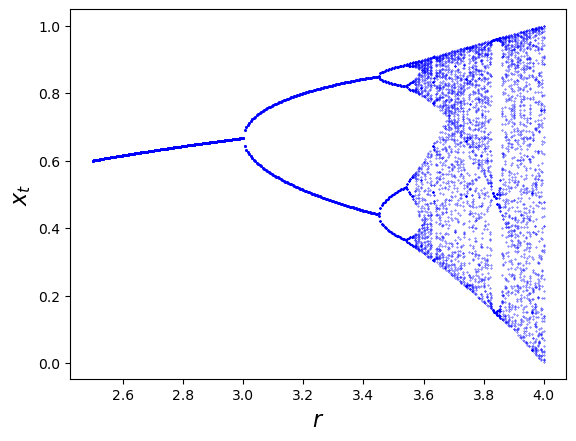

```python
import matplotlib.pyplot as plt
fig, ax = plt.subplots()
ch = Chaos(0.1, 4)
r = 2.5
while r < 4:
    ch.r = r
    t = ch.generate_sequence(1000)[950:]
    ax.plot([r] * len(t), t, 'b.', ms=0.6)
    r = r + 0.005

ax.set_xlabel('$r$', fontsize=16)
ax.set_ylabel('$x_t$', fontsize=16)
plt.show()
```